# Selección de modelos con GridSearchCV

- Domingo José Caballero Navarro
- GitHub Profile: /DomingoJoseCab

## Índice

- 1. Introducción
  - 1.1. Modelos de clasificacións supervisada
  - 1.2. Evaluación de modelos
  - 1.3. Selección de modelos
- 2. Análisis de una libreta de Kaggle
  - 2.1. Reproducción del estudio
  - 2.2. Errores y mejoras de la libreta

# 1. Introducción

En este proyecto veremos como evaluar y seleccionar una serie de modelos, es por ello que todo lo relacionado con el análisis exploratorio de datos y preprocesamiento será el de la proyecto uno. Una vez aclarado esto comenzaremos cargando el conjunto de datos.

```python
random_state = 27912
```

```python
# Standard
import os
from pathlib import Path

# Third party
from sklearn.metrics import check_scoring
from sklearn.model_selection import GridSearchCV, RepeatedStratifiedKFold, train_test_split
from sklearn.ensemble import AdaBoostClassifier, BaggingClassifier, GradientBoostingClassifier, HistGradientBoostingClassifier, RandomForestClassifier
from sklearn.neighbors import KNeighborsClassifier
from sklearn.pipeline import Pipeline
from sklearn.tree import DecisionTreeClassifier
import pandas as pd
```

```python
import os
path = os.path.join(os.path.sep, "data", "workspace_files", "train.csv")
identifier = "PassengerId"
target = "Survived"
dtype = {target: "category"}
arguments = {"filepath_or_buffer": path, "index_col": identifier, "dtype": dtype}
```

```python
import pandas as pd
data = pd.read_csv(**arguments)
```

Una vez hemos cargado el conjunto de datos debemos dividir entre entrenamiento y test.

```python
from sklearn.model_selection import train_test_split
test_size = 0.2

train,test= train_test_split(data, test_size=test_size, random_state=random_state, stratify=data[target])
```

```python
y=train[target]
X=train.drop(target,axis=1)
```

Lo siguiente que realizaremos será crear un preprocesamiento básico, ya creado en la práctica anterior, en el que tenemos un imputador, un normalizador y un encoder. Pero en este caso añadimos la eliminación de las variables predictoras Name, Ticket y Cabin.

```python
from sklearn.compose import make_column_transformer
```

```python
from sklearn.impute import SimpleImputer
```

```python
imputer = make_column_transformer(
    (SimpleImputer(strategy="median"), ["Age", "Fare"]),
    (SimpleImputer(strategy="most_frequent"), ["Embarked", "Sex", "Pclass"]),
    ('drop', ["Name","Ticket","Cabin"]),
    remainder='passthrough'
)
```

```python
from sklearn.preprocessing import MinMaxScaler
```

```python
normalizer = make_column_transformer(
    (MinMaxScaler(feature_range=(0, 1)), ["Age","Fare"]),
    remainder="passthrough"
)
```

```python
from sklearn.preprocessing import OneHotEncoder
```

```python
encoder = make_column_transformer(
    (OneHotEncoder(handle_unknown="ignore", sparse="False"), ["Embarked", "Sex", "Pclass"]),
    remainder="passthrough"
)
```

```python
from sklearn.pipeline import make_pipeline
```

```python
preprocessing = make_pipeline(imputer, normalizer, encoder)
preprocessing
```

```
Pipeline(steps=[('columntransformer-1',
                 ColumnTransformer(remainder='passthrough',
                                   transformers=[('simpleimputer-1',
                                                  SimpleImputer(strategy='median'),
                                                  ['Age', 'Fare']),
                                                 ('simpleimputer-2',
                                                  SimpleImputer(strategy='most_frequent'),
                                                  ['Embarked', 'Sex',
                                                   'Pclass']),
                                                 ('drop', 'drop',
                                                  ['Name', 'Ticket',
                                                   'Cabin'])])),
                ('columntransformer-2',
                 ColumnTransformer(remainder='passthrough',
                                   transformers=[('minmaxscaler',
                                                  MinMaxScaler(),
                                                  ['Age', 'Fare'])])),
                ('columntransformer-3',
                 ColumnTransformer(remainder='passthrough',
                                   transformers=[('onehotencoder',
                                                  OneHotEncoder(handle_unknown='ignore',
                                                                sparse='False'),
                                                  ['Embarked', 'Sex',
                                                   'Pclass'])]))])
```

Podemos observar cómo se muestra el Pipeline de preprocesamiento compuesto por un imputador, un normalizador y un encoder.

```python
def print_feature_indexes(preprocessing, X):
    """Print the index of the features after each step."""
    # Copy the original dataframe to not modify it
    X_copy = X.copy()

    list_indexes = list()

    for index, step in enumerate(preprocessing):
        # Fit the transformer to the modified dataframe
        step.fit(X_copy)

        # Get the name of the features after training the transformer
        feature_names = [name.split("__")[-1] for name in step.get_feature_names_out()]

        # Create the new dataframe with the features provided by the transformer
        X_copy = pd.DataFrame(step.transform(X_copy), columns=feature_names)

        list_indexes.append(list(enumerate(feature_names)))

    return list_indexes
```

```python
indexes = print_feature_indexes(preprocessing,X)
indexes
```

```
[[(0, 'Age'),
  (1, 'Fare'),
  (2, 'Embarked'),
  (3, 'Sex'),
  (4, 'Pclass'),
  (5, 'SibSp'),
  (6, 'Parch')],
 [(0, 'Age'),
  (1, 'Fare'),
  (2, 'Embarked'),
  (3, 'Sex'),
  (4, 'Pclass'),
  (5, 'SibSp'),
  (6, 'Parch')],
 [(0, 'Embarked_C'),
  (1, 'Embarked_Q'),
  (2, 'Embarked_S'),
  (3, 'Sex_female'),
  (4, 'Sex_male'),
  (5, 'Pclass_1'),
  (6, 'Pclass_2'),
  (7, 'Pclass_3'),
  (8, 'Age'),
  (9, 'Fare'),
  (10, 'SibSp'),
  (11, 'Parch')]]
```

```python
def create_pipeline(preprocessing, indexes):
    preprocessors = make_pipeline(preprocessing[0])

    i = 0
    for step in preprocessing[1:]:
        features_indexes = dict([ind[::-1] for ind in indexes[i]])

        for transformer in step.transformers:
            features_in = transformer[2]

            prep_step = make_column_transformer(
            (transformer[1], [features_indexes[feature] for feature in features_in]),
            remainder="passthrough"
            )

            preprocessors.steps.append([transformer[0], prep_step])

        i += 1

    return preprocessors
```

```python
basic_preprocessing = create_pipeline(preprocessing, indexes)
```

```python
basic_preprocessing
```

```
Pipeline(steps=[('columntransformer',
                 ColumnTransformer(remainder='passthrough',
                                   transformers=[('simpleimputer-1',
                                                  SimpleImputer(strategy='median'),
                                                  ['Age', 'Fare']),
                                                 ('simpleimputer-2',
                                                  SimpleImputer(strategy='most_frequent'),
                                                  ['Embarked', 'Sex',
                                                   'Pclass']),
                                                 ('drop', 'drop',
                                                  ['Name', 'Ticket',
                                                   'Cabin'])])),
                ['minmaxscaler',
                 ColumnTransformer(remainder='passthrough',
                                   transformers=[('minmaxscaler',
                                                  MinMaxScaler(), [0, 1])])],
                ['onehotencoder',
                 ColumnTransformer(remainder='passthrough',
                                   transformers=[('onehotencoder',
                                                  OneHotEncoder(handle_unknown='ignore',
                                                                sparse='False'),
                                                  [2, 3, 4])])]])
```

## 1.1. Modelos de clasificación supervisada

Una vez reproducido lo utilizado en la práctica uno y que nos será de utilidad en está práctica podemos comenzar con los distintos modelos. Lo que realizaremos para cada modelo será crear un pipeline con un preprocesamiento básico antes. Y los modelos que utilizaremos son los siguientes: **`KNN`, `árbol de decisión`, `Ada Boost`, `Bagging`, `Random Forest`, `Gradient Boosting` e `Histogram Gradient Boosting`.**

```python
from sklearn.neighbors import KNeighborsClassifier

k_neighbors_model = KNeighborsClassifier()
```

```python
knn_basic_preprocessing = make_pipeline(basic_preprocessing, k_neighbors_model)
```

Como podemos observar creamos un pipeline con el pipeline de preprocesamiento antes creado junto con el modelo, realizaremos la misma tarea con todos los modelos.

```python
from sklearn.tree import DecisionTreeClassifier

decision_tree_model = DecisionTreeClassifier(random_state=random_state)
```

```python
tree_basic_preprocessing = make_pipeline(basic_preprocessing, decision_tree_model)
```

```python
from sklearn.ensemble import AdaBoostClassifier

ada_model = AdaBoostClassifier()
```

```python
ada_basic_preprocessing = make_pipeline(basic_preprocessing, ada_model)
```

```python
from sklearn.ensemble import BaggingClassifier

bagging_model = BaggingClassifier()
```

```python
bagging_basic_preprocessing = make_pipeline(basic_preprocessing, bagging_model)
```

```python
from sklearn.ensemble import RandomForestClassifier

random_forest_model = RandomForestClassifier()
```

```python
random_forest_basic_preprocessing = make_pipeline(basic_preprocessing, random_forest_model)
```

```python
from sklearn.ensemble import GradientBoostingClassifier

gradient_boosting_model = GradientBoostingClassifier()
```

```python
gradient_boosting_basic_preprocessing = make_pipeline(basic_preprocessing, gradient_boosting_model)
```

```python
from sklearn.ensemble import HistGradientBoostingClassifier

hist_gradient_boosting_model = HistGradientBoostingClassifier()
```

```python
hist_gradient_boosting_basic_preprocessing = make_pipeline(basic_preprocessing, hist_gradient_boosting_model)
```

## 1.2. Evaluación de modelos

Una vez que tenemos todos los modelos con su correspondiente pipeline es turno de evaluar que modelo y parámetros son los óptimos para este problema. Para ello realizaremos una búsqueda en malla haciendo uso de la función proporcionada por Juan Carlos Alfaro.

```python
def optimize_params(estimator, X, y, cv, scoring=None, refit=True, **param_grid):
    """Exhaustive search over specified parameter values for an estimator."""
    grid_search_cv = GridSearchCV(estimator,
                                  param_grid,
                                  scoring=scoring,
                                  refit=refit,
                                  cv=cv,
                                  return_train_score=True).fit(X, y)

    cv_results = pd.DataFrame(grid_search_cv.cv_results_)

    # Drop the results for each validation split and sort by the refit metric
    labels = cv_results.filter(regex="split")
    by = cv_results.filter(regex="rank_test").columns[0]
    cv_results = cv_results.drop(labels, axis=1).sort_values(by)

    display(cv_results)

    return grid_search_cv
```

Establecemos una validación cruzada 5x10-fold que utilizaremos para evaluar los diferentes modelos con los diferentes parámetros.

```python
from sklearn.model_selection import RepeatedStratifiedKFold

n_splits = 10
n_repeats = 5

cv = RepeatedStratifiedKFold(n_splits=n_splits, n_repeats=n_repeats, random_state=random_state)
```

La siguiente tarea a realizar es la **selección de parámetros** a comprobar. En el caso de `KNN` comprobaremos con cuantos vecinos funciona mejor y con los pesos de cada vecino, si son pesos uniformes o están pesados con la inversa de la distancia.

```python
from sklearn.model_selection import GridSearchCV

param_grid = {
    'kneighborsclassifier__n_neighbors' : [1, 2, 3, 4, 5, 6, 7, 8],
    'kneighborsclassifier__weights' : ('uniform', 'distance')
}

k_neighbors_classifier = optimize_params(knn_basic_preprocessing, X, y, scoring='roc_auc', cv=cv, **param_grid)
```

|  | mean_fit_time | std_fit_time | mean_score_time | std_score_time | param_kneighborsclassifier__n_neighbors | param_kneighborsclassifier__weights | params | mean_test_score | std_test_score | rank_test_score | mean_train_score | std_train_score |
| --- | --- | --- | --- | --- | --- | --- | --- | --- | --- | --- | --- | --- |
| 14 | 0.050609 | 0.008993 | 0.033830 | 0.008756 | 8 | uniform | {'kneighborsclassifier__n_neighbors': 8, 'knei... | 0.866421 | 0.046419 | 1 | 0.919111 | 0.004557 |
| 12 | 0.046882 | 0.008292 | 0.033027 | 0.009086 | 7 | uniform | {'kneighborsclassifier__n_neighbors': 7, 'knei... | 0.861971 | 0.047049 | 2 | 0.922722 | 0.004482 |
| 10 | 0.050036 | 0.010532 | 0.032713 | 0.008391 | 6 | uniform | {'kneighborsclassifier__n_neighbors': 6, 'knei... | 0.858104 | 0.048295 | 3 | 0.926367 | 0.004017 |
| 15 | 0.048963 | 0.008106 | 0.033044 | 0.010086 | 8 | distance | {'kneighborsclassifier__n_neighbors': 8, 'knei... | 0.855774 | 0.046169 | 4 | 0.999669 | 0.000066 |
| 13 | 0.049622 | 0.009275 | 0.031730 | 0.007668 | 7 | distance | {'kneighborsclassifier__n_neighbors': 7, 'knei... | 0.853334 | 0.046301 | 5 | 0.999669 | 0.000066 |
| 11 | 0.049059 | 0.011012 | 0.032941 | 0.010506 | 6 | distance | {'kneighborsclassifier__n_neighbors': 6, 'knei... | 0.850631 | 0.047056 | 6 | 0.999472 | 0.000608 |
| 8 | 0.021412 | 0.009888 | 0.013824 | 0.006487 | 5 | uniform | {'kneighborsclassifier__n_neighbors': 5, 'knei... | 0.849823 | 0.052170 | 7 | 0.931150 | 0.004064 |
| 6 | 0.017113 | 0.001615 | 0.011113 | 0.001374 | 4 | uniform | {'kneighborsclassifier__n_neighbors': 4, 'knei... | 0.846002 | 0.052203 | 8 | 0.940562 | 0.003911 |
| 9 | 0.048716 | 0.008329 | 0.031764 | 0.007865 | 5 | distance | {'kneighborsclassifier__n_neighbors': 5, 'knei... | 0.845975 | 0.050284 | 9 | 0.997803 | 0.001118 |
| 7 | 0.019123 | 0.004279 | 0.011992 | 0.002954 | 4 | distance | {'kneighborsclassifier__n_neighbors': 4, 'knei... | 0.839868 | 0.050865 | 10 | 0.997073 | 0.000785 |
| 4 | 0.016716 | 0.000304 | 0.010836 | 0.000423 | 3 | uniform | {'kneighborsclassifier__n_neighbors': 3, 'knei... | 0.833821 | 0.052179 | 11 | 0.951026 | 0.003198 |
| 5 | 0.016925 | 0.001687 | 0.011041 | 0.001800 | 3 | distance | {'kneighborsclassifier__n_neighbors': 3, 'knei... | 0.827141 | 0.050838 | 12 | 0.996888 | 0.000750 |
| 2 | 0.016802 | 0.000363 | 0.010788 | 0.000272 | 2 | uniform | {'kneighborsclassifier__n_neighbors': 2, 'knei... | 0.807892 | 0.055023 | 13 | 0.969421 | 0.002089 |
| 3 | 0.016586 | 0.000373 | 0.010645 | 0.000241 | 2 | distance | {'kneighborsclassifier__n_neighbors': 2, 'knei... | 0.805734 | 0.053475 | 14 | 0.996809 | 0.000685 |
| 0 | 0.016889 | 0.000393 | 0.010693 | 0.000417 | 1 | uniform | {'kneighborsclassifier__n_neighbors': 1, 'knei... | 0.757080 | 0.060488 | 15 | 0.988004 | 0.001404 |
| 1 | 0.016999 | 0.000603 | 0.010900 | 0.000410 | 1 | distance | {'kneighborsclassifier__n_neighbors': 1, 'knei... | 0.757080 | 0.060488 | 15 | 0.988004 | 0.001404 |

En el caso del `árbol de decisión` probaremos criterio para evaluar la ganancia de información es mejor, si gini o entropía. También comprobaremos que profundidad máxima es mejor o si es mejor no establecer una. Por último, comprobaremos que coste para la poda es mejor.

```python
param_grid = {
    'decisiontreeclassifier__criterion' : ('gini', 'entropy'),
    'decisiontreeclassifier__max_depth' : [1, 2, 3, 4, 5, 6, None],
    'decisiontreeclassifier__ccp_alpha' : [0.0, 0.01, 0.02, 0.03, 0.04, 0.05]
}

decision_tree_classifier = optimize_params(tree_basic_preprocessing, X, y, scoring='roc_auc', cv=cv, **param_grid)
```

|  | mean_fit_time | std_fit_time | mean_score_time | std_score_time | param_decisiontreeclassifier__ccp_alpha | param_decisiontreeclassifier__criterion | param_decisiontreeclassifier__max_depth | params | mean_test_score | std_test_score | rank_test_score | mean_train_score | std_train_score |
| --- | --- | --- | --- | --- | --- | --- | --- | --- | --- | --- | --- | --- | --- |
| 20 | 0.017585 | 0.000318 | 0.009588 | 0.000239 | 0.01 | gini | None | {'decisiontreeclassifier__ccp_alpha': 0.01, 'd... | 0.852329 | 0.052419 | 1 | 0.874414 | 0.006925 |
| 19 | 0.017303 | 0.000343 | 0.009715 | 0.000341 | 0.01 | gini | 6 | {'decisiontreeclassifier__ccp_alpha': 0.01, 'd... | 0.852329 | 0.052419 | 1 | 0.874414 | 0.006925 |
| 18 | 0.017136 | 0.000276 | 0.009533 | 0.000169 | 0.01 | gini | 5 | {'decisiontreeclassifier__ccp_alpha': 0.01, 'd... | 0.852329 | 0.052419 | 1 | 0.874414 | 0.006925 |
| 17 | 0.017225 | 0.000373 | 0.009691 | 0.000237 | 0.01 | gini | 4 | {'decisiontreeclassifier__ccp_alpha': 0.01, 'd... | 0.852329 | 0.052419 | 1 | 0.874414 | 0.006925 |
| 27 | 0.018174 | 0.000273 | 0.009843 | 0.000175 | 0.01 | entropy | None | {'decisiontreeclassifier__ccp_alpha': 0.01, 'd... | 0.851058 | 0.057526 | 5 | 0.886988 | 0.007704 |
| ... | ... | ... | ... | ... | ... | ... | ... | ... | ... | ... | ... | ... | ... |
| 42 | 0.017074 | 0.000372 | 0.009752 | 0.000224 | 0.03 | gini | 1 | {'decisiontreeclassifier__ccp_alpha': 0.03, 'd... | 0.766132 | 0.050272 | 67 | 0.765983 | 0.005597 |
| 63 | 0.048978 | 0.008852 | 0.027394 | 0.007338 | 0.04 | entropy | 1 | {'decisiontreeclassifier__ccp_alpha': 0.04, 'd... | 0.766132 | 0.050272 | 67 | 0.765983 | 0.005597 |
| 56 | 0.050361 | 0.008115 | 0.028863 | 0.008006 | 0.04 | gini | 1 | {'decisiontreeclassifier__ccp_alpha': 0.04, 'd... | 0.766132 | 0.050272 | 67 | 0.765983 | 0.005597 |
| 72 | 0.051323 | 0.008284 | 0.026955 | 0.007334 | 0.05 | gini | 3 | {'decisiontreeclassifier__ccp_alpha': 0.05, 'd... | 0.766132 | 0.050272 | 67 | 0.765983 | 0.005597 |
| 0 | 0.053940 | 0.014323 | 0.032980 | 0.011019 | 0.0 | gini | 1 | {'decisiontreeclassifier__ccp_alpha': 0.0, 'de... | 0.766132 | 0.050272 | 67 | 0.765983 | 0.005597 |

84 rows × 13 columns

En el caso de `Ada Boost` tendremos que definir un estimador base, que se trata de un árbol de decisión en el que probaremos que criterio de ganancia de información es mejor y que profundidad máxima es mejor. En cuanto a Ada Boost comprobaremos el número de estimadores óptimos.

```python
base_estimator = DecisionTreeClassifier(random_state=random_state)
param_grid = {
    'adaboostclassifier__base_estimator' : [base_estimator],
    'adaboostclassifier__n_estimators' : [20, 50, 100],
    'adaboostclassifier__learning_rate' : [0.95, 1.0],
    'adaboostclassifier__base_estimator__max_depth' : [1, 2, 3],
    'adaboostclassifier__base_estimator__criterion' : ["gini", "entropy"]
}

adaboost_classifier = optimize_params(ada_basic_preprocessing, X, y, scoring='roc_auc', cv=cv, **param_grid)
```

|  | mean_fit_time | std_fit_time | mean_score_time | std_score_time | param_adaboostclassifier__base_estimator | param_adaboostclassifier__base_estimator__criterion | param_adaboostclassifier__base_estimator__max_depth | param_adaboostclassifier__learning_rate | param_adaboostclassifier__n_estimators | params | mean_test_score | std_test_score | rank_test_score | mean_train_score | std_train_score |
| --- | --- | --- | --- | --- | --- | --- | --- | --- | --- | --- | --- | --- | --- | --- | --- |
| 21 | 0.205089 | 0.011629 | 0.044497 | 0.008377 | DecisionTreeClassifier(criterion='entropy', ma... | entropy | 1 | 1.0 | 20 | {'adaboostclassifier__base_estimator': Decisio... | 0.852893 | 0.043255 | 1 | 0.890671 | 0.005404 |
| 3 | 0.071225 | 0.000890 | 0.014829 | 0.000190 | DecisionTreeClassifier(criterion='entropy', ma... | gini | 1 | 1.0 | 20 | {'adaboostclassifier__base_estimator': Decisio... | 0.852755 | 0.044402 | 2 | 0.891401 | 0.005334 |
| 0 | 0.135421 | 0.068955 | 0.028245 | 0.015362 | DecisionTreeClassifier(criterion='entropy', ma... | gini | 1 | 0.95 | 20 | {'adaboostclassifier__base_estimator': Decisio... | 0.852062 | 0.044799 | 3 | 0.890399 | 0.005302 |
| 6 | 0.210457 | 0.011523 | 0.043211 | 0.009705 | DecisionTreeClassifier(criterion='entropy', ma... | gini | 2 | 0.95 | 20 | {'adaboostclassifier__base_estimator': Decisio... | 0.851404 | 0.055136 | 4 | 0.951248 | 0.004995 |
| 9 | 0.282261 | 0.169608 | 0.056970 | 0.036250 | DecisionTreeClassifier(criterion='entropy', ma... | gini | 2 | 1.0 | 20 | {'adaboostclassifier__base_estimator': Decisio... | 0.850397 | 0.047127 | 5 | 0.950818 | 0.004905 |
| 19 | 0.449745 | 0.019985 | 0.065233 | 0.009678 | DecisionTreeClassifier(criterion='entropy', ma... | entropy | 1 | 0.95 | 50 | {'adaboostclassifier__base_estimator': Decisio... | 0.849752 | 0.045106 | 6 | 0.908468 | 0.004976 |
| 4 | 0.155077 | 0.000873 | 0.022440 | 0.000300 | DecisionTreeClassifier(criterion='entropy', ma... | gini | 1 | 1.0 | 50 | {'adaboostclassifier__base_estimator': Decisio... | 0.849640 | 0.042567 | 7 | 0.909369 | 0.004926 |
| 18 | 0.205173 | 0.014394 | 0.041087 | 0.005404 | DecisionTreeClassifier(criterion='entropy', ma... | entropy | 1 | 0.95 | 20 | {'adaboostclassifier__base_estimator': Decisio... | 0.849396 | 0.043672 | 8 | 0.890505 | 0.005011 |
| 1 | 0.155976 | 0.002007 | 0.022709 | 0.000708 | DecisionTreeClassifier(criterion='entropy', ma... | gini | 1 | 0.95 | 50 | {'adaboostclassifier__base_estimator': Decisio... | 0.849170 | 0.044906 | 9 | 0.908482 | 0.004550 |
| 22 | 0.453551 | 0.020235 | 0.066376 | 0.008012 | DecisionTreeClassifier(criterion='entropy', ma... | entropy | 1 | 1.0 | 50 | {'adaboostclassifier__base_estimator': Decisio... | 0.848922 | 0.044584 | 10 | 0.909345 | 0.004755 |
| 5 | 0.338916 | 0.128196 | 0.039779 | 0.016814 | DecisionTreeClassifier(criterion='entropy', ma... | gini | 1 | 1.0 | 100 | {'adaboostclassifier__base_estimator': Decisio... | 0.848769 | 0.045101 | 11 | 0.920718 | 0.004421 |
| 20 | 0.923852 | 0.246232 | 0.115913 | 0.065357 | DecisionTreeClassifier(criterion='entropy', ma... | entropy | 1 | 0.95 | 100 | {'adaboostclassifier__base_estimator': Decisio... | 0.848735 | 0.044218 | 12 | 0.919302 | 0.004381 |
| 23 | 0.763455 | 0.201732 | 0.089277 | 0.025679 | DecisionTreeClassifier(criterion='entropy', ma... | entropy | 1 | 1.0 | 100 | {'adaboostclassifier__base_estimator': Decisio... | 0.847776 | 0.044634 | 13 | 0.920843 | 0.004191 |
| 2 | 0.295098 | 0.002449 | 0.034898 | 0.000741 | DecisionTreeClassifier(criterion='entropy', ma... | gini | 1 | 0.95 | 100 | {'adaboostclassifier__base_estimator': Decisio... | 0.847758 | 0.044840 | 14 | 0.919380 | 0.004396 |
| 27 | 0.075040 | 0.000881 | 0.014912 | 0.000193 | DecisionTreeClassifier(criterion='entropy', ma... | entropy | 2 | 1.0 | 20 | {'adaboostclassifier__base_estimator': Decisio... | 0.842729 | 0.050190 | 15 | 0.950566 | 0.005073 |
| 24 | 0.075239 | 0.000460 | 0.015041 | 0.000180 | DecisionTreeClassifier(criterion='entropy', ma... | entropy | 2 | 0.95 | 20 | {'adaboostclassifier__base_estimator': Decisio... | 0.838014 | 0.053436 | 16 | 0.948422 | 0.004699 |
| 7 | 0.463142 | 0.020247 | 0.065006 | 0.009085 | DecisionTreeClassifier(criterion='entropy', ma... | gini | 2 | 0.95 | 50 | {'adaboostclassifier__base_estimator': Decisio... | 0.831360 | 0.049040 | 17 | 0.984331 | 0.002360 |
| 10 | 0.474860 | 0.028136 | 0.066635 | 0.011228 | DecisionTreeClassifier(criterion='entropy', ma... | gini | 2 | 1.0 | 50 | {'adaboostclassifier__base_estimator': Decisio... | 0.828183 | 0.043286 | 18 | 0.984314 | 0.002850 |
| 8 | 0.889029 | 0.025813 | 0.100119 | 0.009489 | DecisionTreeClassifier(criterion='entropy', ma... | gini | 2 | 0.95 | 100 | {'adaboostclassifier__base_estimator': Decisio... | 0.824899 | 0.044509 | 19 | 0.997123 | 0.000708 |
| 32 | 0.952408 | 0.033291 | 0.099771 | 0.011825 | DecisionTreeClassifier(criterion='entropy', ma... | entropy | 3 | 0.95 | 100 | {'adaboostclassifier__base_estimator': Decisio... | 0.822794 | 0.052546 | 20 | 0.999669 | 0.000066 |
| 11 | 0.891942 | 0.026018 | 0.101971 | 0.010027 | DecisionTreeClassifier(criterion='entropy', ma... | gini | 2 | 1.0 | 100 | {'adaboostclassifier__base_estimator': Decisio... | 0.820398 | 0.048738 | 21 | 0.997338 | 0.000717 |
| 28 | 0.164811 | 0.000997 | 0.022749 | 0.000380 | DecisionTreeClassifier(criterion='entropy', ma... | entropy | 2 | 1.0 | 50 | {'adaboostclassifier__base_estimator': Decisio... | 0.819717 | 0.046360 | 22 | 0.985361 | 0.002844 |
| 29 | 0.599664 | 0.282908 | 0.067720 | 0.031692 | DecisionTreeClassifier(criterion='entropy', ma... | entropy | 2 | 1.0 | 100 | {'adaboostclassifier__base_estimator': Decisio... | 0.818334 | 0.048149 | 23 | 0.997726 | 0.000580 |
| 12 | 0.111417 | 0.064626 | 0.020899 | 0.011334 | DecisionTreeClassifier(criterion='entropy', ma... | gini | 3 | 0.95 | 20 | {'adaboostclassifier__base_estimator': Decisio... | 0.817544 | 0.053815 | 24 | 0.985746 | 0.002243 |
| 14 | 0.323291 | 0.002489 | 0.035359 | 0.000936 | DecisionTreeClassifier(criterion='entropy', ma... | gini | 3 | 0.95 | 100 | {'adaboostclassifier__base_estimator': Decisio... | 0.816746 | 0.053217 | 25 | 0.999669 | 0.000066 |
| 25 | 0.164094 | 0.000868 | 0.022560 | 0.000406 | DecisionTreeClassifier(criterion='entropy', ma... | entropy | 2 | 0.95 | 50 | {'adaboostclassifier__base_estimator': Decisio... | 0.816458 | 0.046726 | 26 | 0.985052 | 0.002744 |
| 30 | 0.223593 | 0.015381 | 0.041759 | 0.007471 | DecisionTreeClassifier(criterion='entropy', ma... | entropy | 3 | 0.95 | 20 | {'adaboostclassifier__base_estimator': Decisio... | 0.815906 | 0.053339 | 27 | 0.984606 | 0.003387 |
| 35 | 0.701348 | 0.501920 | 0.074671 | 0.068358 | DecisionTreeClassifier(criterion='entropy', ma... | entropy | 3 | 1.0 | 100 | {'adaboostclassifier__base_estimator': Decisio... | 0.814385 | 0.039850 | 28 | 0.999669 | 0.000066 |
| 31 | 0.486932 | 0.013597 | 0.063269 | 0.009456 | DecisionTreeClassifier(criterion='entropy', ma... | entropy | 3 | 0.95 | 50 | {'adaboostclassifier__base_estimator': Decisio... | 0.810990 | 0.051269 | 29 | 0.999579 | 0.000103 |
| 17 | 0.562391 | 0.293487 | 0.061239 | 0.032843 | DecisionTreeClassifier(criterion='entropy', ma... | gini | 3 | 1.0 | 100 | {'adaboostclassifier__base_estimator': Decisio... | 0.807958 | 0.054145 | 30 | 0.999669 | 0.000066 |
| 15 | 0.077783 | 0.001317 | 0.015170 | 0.000282 | DecisionTreeClassifier(criterion='entropy', ma... | gini | 3 | 1.0 | 20 | {'adaboostclassifier__base_estimator': Decisio... | 0.807399 | 0.049162 | 31 | 0.986524 | 0.002473 |
| 26 | 0.313027 | 0.001787 | 0.034918 | 0.000369 | DecisionTreeClassifier(criterion='entropy', ma... | entropy | 2 | 0.95 | 100 | {'adaboostclassifier__base_estimator': Decisio... | 0.806275 | 0.043963 | 32 | 0.997656 | 0.000623 |
| 33 | 0.245942 | 0.058404 | 0.047284 | 0.016842 | DecisionTreeClassifier(criterion='entropy', ma... | entropy | 3 | 1.0 | 20 | {'adaboostclassifier__base_estimator': Decisio... | 0.806199 | 0.052670 | 33 | 0.985748 | 0.003140 |
| 13 | 0.169936 | 0.002490 | 0.022860 | 0.000572 | DecisionTreeClassifier(criterion='entropy', ma... | gini | 3 | 0.95 | 50 | {'adaboostclassifier__base_estimator': Decisio... | 0.806043 | 0.053876 | 34 | 0.999522 | 0.000107 |
| 34 | 0.500588 | 0.027371 | 0.067527 | 0.009730 | DecisionTreeClassifier(criterion='entropy', ma... | entropy | 3 | 1.0 | 50 | {'adaboostclassifier__base_estimator': Decisio... | 0.801788 | 0.053437 | 35 | 0.999578 | 0.000105 |
| 16 | 0.170912 | 0.003199 | 0.022910 | 0.000493 | DecisionTreeClassifier(criterion='entropy', ma... | gini | 3 | 1.0 | 50 | {'adaboostclassifier__base_estimator': Decisio... | 0.795865 | 0.049865 | 36 | 0.999547 | 0.000111 |

En cuanto a `Bagging` sucede los mismo que con Ada Boost establecemos un estimador base que será un árbol de decisión. Además, probaremos el número de estimadores y el número de variables predictoras máximo.

```python
base_estimator = DecisionTreeClassifier(random_state=random_state)
param_grid = {
    'baggingclassifier__base_estimator' : [base_estimator],
    'baggingclassifier__n_estimators' : [20, 50, 100],
    'baggingclassifier__max_features' : [1,3,5,6,7,8],
    'baggingclassifier__base_estimator__criterion' : ["gini", "entropy"]
}

bagging_classifier = optimize_params(bagging_basic_preprocessing, X, y, scoring='roc_auc', cv=cv, **param_grid)
```

|  | mean_fit_time | std_fit_time | mean_score_time | std_score_time | param_baggingclassifier__base_estimator | param_baggingclassifier__base_estimator__criterion | param_baggingclassifier__max_features | param_baggingclassifier__n_estimators | params | mean_test_score | std_test_score | rank_test_score | mean_train_score | std_train_score |
| --- | --- | --- | --- | --- | --- | --- | --- | --- | --- | --- | --- | --- | --- | --- |
| 29 | 0.474206 | 0.262484 | 0.048767 | 0.026566 | DecisionTreeClassifier(criterion='entropy', ra... | entropy | 6 | 100 | {'baggingclassifier__base_estimator': Decision... | 0.898262 | 0.036972 | 1 | 0.992659 | 0.001604 |
| 26 | 0.717010 | 0.027853 | 0.080347 | 0.010066 | DecisionTreeClassifier(criterion='entropy', ra... | entropy | 5 | 100 | {'baggingclassifier__base_estimator': Decision... | 0.898050 | 0.036908 | 2 | 0.987915 | 0.002686 |
| 32 | 0.273872 | 0.003834 | 0.028764 | 0.001143 | DecisionTreeClassifier(criterion='entropy', ra... | entropy | 7 | 100 | {'baggingclassifier__base_estimator': Decision... | 0.897714 | 0.035587 | 3 | 0.995159 | 0.000939 |
| 8 | 0.690094 | 0.060589 | 0.075414 | 0.009213 | DecisionTreeClassifier(criterion='entropy', ra... | gini | 5 | 100 | {'baggingclassifier__base_estimator': Decision... | 0.897329 | 0.035268 | 4 | 0.988507 | 0.002214 |
| 11 | 0.714313 | 0.022441 | 0.078446 | 0.009128 | DecisionTreeClassifier(criterion='entropy', ra... | gini | 6 | 100 | {'baggingclassifier__base_estimator': Decision... | 0.897205 | 0.035077 | 5 | 0.992755 | 0.001415 |
| 28 | 0.448418 | 0.112419 | 0.062940 | 0.023466 | DecisionTreeClassifier(criterion='entropy', ra... | entropy | 6 | 50 | {'baggingclassifier__base_estimator': Decision... | 0.896619 | 0.035418 | 6 | 0.991900 | 0.002365 |
| 10 | 0.379848 | 0.021272 | 0.052553 | 0.008281 | DecisionTreeClassifier(criterion='entropy', ra... | gini | 6 | 50 | {'baggingclassifier__base_estimator': Decision... | 0.895987 | 0.037625 | 7 | 0.992237 | 0.002139 |
| 7 | 0.358889 | 0.016717 | 0.054154 | 0.008689 | DecisionTreeClassifier(criterion='entropy', ra... | gini | 5 | 50 | {'baggingclassifier__base_estimator': Decision... | 0.895873 | 0.038733 | 8 | 0.987301 | 0.004015 |
| 14 | 0.527672 | 0.246930 | 0.055962 | 0.026073 | DecisionTreeClassifier(criterion='entropy', ra... | gini | 7 | 100 | {'baggingclassifier__base_estimator': Decision... | 0.895183 | 0.037658 | 9 | 0.995098 | 0.000974 |
| 13 | 0.396132 | 0.016879 | 0.057368 | 0.012875 | DecisionTreeClassifier(criterion='entropy', ra... | gini | 7 | 50 | {'baggingclassifier__base_estimator': Decision... | 0.894838 | 0.035475 | 10 | 0.994727 | 0.001503 |
| 25 | 0.381047 | 0.018175 | 0.052945 | 0.008768 | DecisionTreeClassifier(criterion='entropy', ra... | entropy | 5 | 50 | {'baggingclassifier__base_estimator': Decision... | 0.894397 | 0.033557 | 11 | 0.987229 | 0.003475 |
| 17 | 0.270035 | 0.009263 | 0.028732 | 0.000572 | DecisionTreeClassifier(criterion='entropy', ra... | gini | 8 | 100 | {'baggingclassifier__base_estimator': Decision... | 0.893463 | 0.039138 | 12 | 0.996565 | 0.000676 |
| 31 | 0.145613 | 0.002350 | 0.019625 | 0.000501 | DecisionTreeClassifier(criterion='entropy', ra... | entropy | 7 | 50 | {'baggingclassifier__base_estimator': Decision... | 0.893093 | 0.038365 | 13 | 0.994779 | 0.001518 |
| 24 | 0.181258 | 0.013378 | 0.036441 | 0.008078 | DecisionTreeClassifier(criterion='entropy', ra... | entropy | 5 | 20 | {'baggingclassifier__base_estimator': Decision... | 0.892881 | 0.035817 | 14 | 0.983676 | 0.006097 |
| 9 | 0.176000 | 0.013638 | 0.040347 | 0.008963 | DecisionTreeClassifier(criterion='entropy', ra... | gini | 6 | 20 | {'baggingclassifier__base_estimator': Decision... | 0.892116 | 0.037624 | 15 | 0.990358 | 0.004140 |
| 35 | 0.622839 | 0.426954 | 0.065215 | 0.051975 | DecisionTreeClassifier(criterion='entropy', ra... | entropy | 8 | 100 | {'baggingclassifier__base_estimator': Decision... | 0.892105 | 0.037038 | 16 | 0.996652 | 0.000708 |
| 34 | 0.150409 | 0.004602 | 0.019584 | 0.000288 | DecisionTreeClassifier(criterion='entropy', ra... | entropy | 8 | 50 | {'baggingclassifier__base_estimator': Decision... | 0.891689 | 0.038775 | 17 | 0.996383 | 0.000806 |
| 22 | 0.354783 | 0.019566 | 0.051754 | 0.008984 | DecisionTreeClassifier(criterion='entropy', ra... | entropy | 3 | 50 | {'baggingclassifier__base_estimator': Decision... | 0.890092 | 0.038301 | 18 | 0.965517 | 0.008030 |
| 27 | 0.224814 | 0.103988 | 0.049381 | 0.030642 | DecisionTreeClassifier(criterion='entropy', ra... | entropy | 6 | 20 | {'baggingclassifier__base_estimator': Decision... | 0.890047 | 0.037163 | 19 | 0.990791 | 0.003508 |
| 16 | 0.142692 | 0.001319 | 0.019640 | 0.000280 | DecisionTreeClassifier(criterion='entropy', ra... | gini | 8 | 50 | {'baggingclassifier__base_estimator': Decision... | 0.889913 | 0.038822 | 20 | 0.996277 | 0.000938 |
| 5 | 0.225904 | 0.003775 | 0.026533 | 0.000352 | DecisionTreeClassifier(criterion='entropy', ra... | gini | 3 | 100 | {'baggingclassifier__base_estimator': Decision... | 0.889229 | 0.037403 | 21 | 0.966982 | 0.005799 |
| 12 | 0.195414 | 0.017341 | 0.041095 | 0.007765 | DecisionTreeClassifier(criterion='entropy', ra... | gini | 7 | 20 | {'baggingclassifier__base_estimator': Decision... | 0.888623 | 0.040819 | 22 | 0.992981 | 0.002661 |
| 6 | 0.078724 | 0.030421 | 0.017633 | 0.007631 | DecisionTreeClassifier(criterion='entropy', ra... | gini | 5 | 20 | {'baggingclassifier__base_estimator': Decision... | 0.888569 | 0.040109 | 23 | 0.984981 | 0.005668 |
| 23 | 0.646231 | 0.025711 | 0.073949 | 0.011583 | DecisionTreeClassifier(criterion='entropy', ra... | entropy | 3 | 100 | {'baggingclassifier__base_estimator': Decision... | 0.887031 | 0.039770 | 24 | 0.967031 | 0.005881 |
| 30 | 0.068309 | 0.001434 | 0.014034 | 0.000279 | DecisionTreeClassifier(criterion='entropy', ra... | entropy | 7 | 20 | {'baggingclassifier__base_estimator': Decision... | 0.886196 | 0.039586 | 25 | 0.992984 | 0.003306 |
| 33 | 0.070456 | 0.001198 | 0.014118 | 0.000345 | DecisionTreeClassifier(criterion='entropy', ra... | entropy | 8 | 20 | {'baggingclassifier__base_estimator': Decision... | 0.885452 | 0.040502 | 26 | 0.995356 | 0.001397 |
| 4 | 0.120188 | 0.001265 | 0.018390 | 0.000218 | DecisionTreeClassifier(criterion='entropy', ra... | gini | 3 | 50 | {'baggingclassifier__base_estimator': Decision... | 0.883704 | 0.038472 | 27 | 0.965607 | 0.008282 |
| 15 | 0.067464 | 0.001358 | 0.014094 | 0.000274 | DecisionTreeClassifier(criterion='entropy', ra... | gini | 8 | 20 | {'baggingclassifier__base_estimator': Decision... | 0.881668 | 0.040526 | 28 | 0.995046 | 0.002074 |
| 21 | 0.109526 | 0.047172 | 0.025828 | 0.013617 | DecisionTreeClassifier(criterion='entropy', ra... | entropy | 3 | 20 | {'baggingclassifier__base_estimator': Decision... | 0.874701 | 0.043219 | 29 | 0.956984 | 0.016424 |
| 3 | 0.057963 | 0.000983 | 0.013469 | 0.000191 | DecisionTreeClassifier(criterion='entropy', ra... | gini | 3 | 20 | {'baggingclassifier__base_estimator': Decision... | 0.871961 | 0.046392 | 30 | 0.957998 | 0.015621 |
| 20 | 0.212629 | 0.008168 | 0.025836 | 0.002257 | DecisionTreeClassifier(criterion='entropy', ra... | entropy | 1 | 100 | {'baggingclassifier__base_estimator': Decision... | 0.863952 | 0.045654 | 31 | 0.919872 | 0.010446 |
| 2 | 0.205770 | 0.001786 | 0.025101 | 0.000357 | DecisionTreeClassifier(criterion='entropy', ra... | gini | 1 | 100 | {'baggingclassifier__base_estimator': Decision... | 0.860450 | 0.041890 | 32 | 0.921244 | 0.010018 |
| 19 | 0.112807 | 0.001978 | 0.017761 | 0.000329 | DecisionTreeClassifier(criterion='entropy', ra... | entropy | 1 | 50 | {'baggingclassifier__base_estimator': Decision... | 0.857707 | 0.050638 | 33 | 0.917190 | 0.012365 |
| 1 | 0.111123 | 0.001170 | 0.017664 | 0.000232 | DecisionTreeClassifier(criterion='entropy', ra... | gini | 1 | 50 | {'baggingclassifier__base_estimator': Decision... | 0.856599 | 0.046615 | 34 | 0.913304 | 0.015584 |
| 0 | 0.054360 | 0.000663 | 0.013316 | 0.000241 | DecisionTreeClassifier(criterion='entropy', ra... | gini | 1 | 20 | {'baggingclassifier__base_estimator': Decision... | 0.831648 | 0.061861 | 35 | 0.895173 | 0.025946 |
| 18 | 0.055022 | 0.000776 | 0.013356 | 0.000201 | DecisionTreeClassifier(criterion='entropy', ra... | entropy | 1 | 20 | {'baggingclassifier__base_estimator': Decision... | 0.830379 | 0.061114 | 36 | 0.894452 | 0.028436 |

En cuanto a `Random Forest` evaluamos el número de estimadores óptimo y que criterio para evaluar la ganancia de información es mejor, si gini o entropía. Además, evaluamos métrica para seleccionar el número de variables predictoras es mejor, si la raíz cuadra de N o la función logarítmica en base 2 de N, dónde N es el número de variables predictoras en nuestro problema.

```python
param_grid = {
    'randomforestclassifier__max_features' : ["sqrt", "log2"],
    'randomforestclassifier__n_estimators' : [20, 50, 100],
    'randomforestclassifier__criterion' : ["gini", "entropy"]
}

random_forest_classifier = optimize_params(random_forest_basic_preprocessing, X, y, scoring='roc_auc', cv=cv, **param_grid)
```

|  | mean_fit_time | std_fit_time | mean_score_time | std_score_time | param_randomforestclassifier__criterion | param_randomforestclassifier__max_features | param_randomforestclassifier__n_estimators | params | mean_test_score | std_test_score | rank_test_score | mean_train_score | std_train_score |
| --- | --- | --- | --- | --- | --- | --- | --- | --- | --- | --- | --- | --- | --- |
| 8 | 0.352816 | 0.189590 | 0.043317 | 0.024068 | entropy | sqrt | 100 | {'randomforestclassifier__criterion': 'entropy... | 0.881682 | 0.041863 | 1 | 0.998462 | 0.000312 |
| 4 | 0.303549 | 0.013796 | 0.052753 | 0.009198 | gini | log2 | 50 | {'randomforestclassifier__criterion': 'gini', ... | 0.881439 | 0.038735 | 2 | 0.998325 | 0.000319 |
| 5 | 0.650834 | 0.223355 | 0.083857 | 0.031333 | gini | log2 | 100 | {'randomforestclassifier__criterion': 'gini', ... | 0.881255 | 0.040197 | 3 | 0.998463 | 0.000314 |
| 11 | 0.210921 | 0.001576 | 0.026361 | 0.000334 | entropy | log2 | 100 | {'randomforestclassifier__criterion': 'entropy... | 0.881134 | 0.040873 | 4 | 0.998459 | 0.000281 |
| 2 | 0.571448 | 0.018195 | 0.073920 | 0.011011 | gini | sqrt | 100 | {'randomforestclassifier__criterion': 'gini', ... | 0.881076 | 0.041100 | 5 | 0.998458 | 0.000319 |
| 1 | 0.308025 | 0.019530 | 0.054519 | 0.011390 | gini | sqrt | 50 | {'randomforestclassifier__criterion': 'gini', ... | 0.878271 | 0.043088 | 6 | 0.998309 | 0.000326 |
| 10 | 0.116855 | 0.009517 | 0.018371 | 0.000282 | entropy | log2 | 50 | {'randomforestclassifier__criterion': 'entropy... | 0.877922 | 0.041765 | 7 | 0.998339 | 0.000371 |
| 7 | 0.317490 | 0.014272 | 0.049695 | 0.007464 | entropy | sqrt | 50 | {'randomforestclassifier__criterion': 'entropy... | 0.877848 | 0.040863 | 8 | 0.998352 | 0.000346 |
| 6 | 0.160357 | 0.013321 | 0.040192 | 0.009010 | entropy | sqrt | 20 | {'randomforestclassifier__criterion': 'entropy... | 0.877076 | 0.043248 | 9 | 0.997895 | 0.000462 |
| 3 | 0.153219 | 0.013167 | 0.037351 | 0.007376 | gini | log2 | 20 | {'randomforestclassifier__criterion': 'gini', ... | 0.873247 | 0.044553 | 10 | 0.997896 | 0.000470 |
| 9 | 0.055766 | 0.000733 | 0.013500 | 0.000218 | entropy | log2 | 20 | {'randomforestclassifier__criterion': 'entropy... | 0.873104 | 0.042897 | 11 | 0.997955 | 0.000484 |
| 0 | 0.157883 | 0.015084 | 0.037864 | 0.007971 | gini | sqrt | 20 | {'randomforestclassifier__criterion': 'gini', ... | 0.872860 | 0.041772 | 12 | 0.997946 | 0.000475 |

En el caso de `Gradient Boosting` evaluaremos que tasa de aprendizaje es mejor, que número de estimadores es mejor y que profundidad máxima es la óptima. Además, evaluaremos que criterio de partición es mejor, si el error cuadrático medio básico o con la mejora de Friedman.

```python
param_grid = {
    'gradientboostingclassifier__learning_rate' : [0.01, 0.05, 0.1],
    'gradientboostingclassifier__criterion' : ["friedman_mse", "squared_error"],
    'gradientboostingclassifier__n_estimators' : [20, 50, 100],
    'gradientboostingclassifier__max_depth' : [1, 2, 3, 4, 5, 6, None]
}

gradient_boosting_classifier = optimize_params(gradient_boosting_basic_preprocessing, X, y, scoring='roc_auc', cv=cv, **param_grid)
```

|  | mean_fit_time | std_fit_time | mean_score_time | std_score_time | param_gradientboostingclassifier__criterion | param_gradientboostingclassifier__learning_rate | param_gradientboostingclassifier__max_depth | param_gradientboostingclassifier__n_estimators | params | mean_test_score | std_test_score | rank_test_score | mean_train_score | std_train_score |
| --- | --- | --- | --- | --- | --- | --- | --- | --- | --- | --- | --- | --- | --- | --- |
| 35 | 0.633559 | 0.036514 | 0.033033 | 0.008785 | friedman_mse | 0.05 | 5 | 100 | {'gradientboostingclassifier__criterion': 'fri... | 0.883493 | 0.039218 | 1 | 0.986797 | 0.001588 |
| 98 | 0.620840 | 0.026937 | 0.027865 | 0.006126 | squared_error | 0.05 | 5 | 100 | {'gradientboostingclassifier__criterion': 'squ... | 0.883339 | 0.039454 | 2 | 0.986779 | 0.001596 |
| 55 | 0.120589 | 0.002691 | 0.010691 | 0.000315 | friedman_mse | 0.1 | 5 | 50 | {'gradientboostingclassifier__criterion': 'fri... | 0.883308 | 0.039131 | 3 | 0.986915 | 0.001947 |
| 118 | 0.329015 | 0.016201 | 0.029804 | 0.007250 | squared_error | 0.1 | 5 | 50 | {'gradientboostingclassifier__criterion': 'squ... | 0.883117 | 0.038876 | 4 | 0.987006 | 0.001943 |
| 32 | 0.469407 | 0.018967 | 0.029996 | 0.007991 | friedman_mse | 0.05 | 4 | 100 | {'gradientboostingclassifier__criterion': 'fri... | 0.879563 | 0.042677 | 5 | 0.968167 | 0.002658 |
| ... | ... | ... | ... | ... | ... | ... | ... | ... | ... | ... | ... | ... | ... | ... |
| 123 | 0.344239 | 0.123448 | 0.023879 | 0.010688 | squared_error | 0.1 | None | 20 | {'gradientboostingclassifier__criterion': 'squ... | 0.782704 | 0.050676 | 122 | 0.999669 | 0.000066 |
| 1 | 0.049292 | 0.000497 | 0.010237 | 0.000201 | friedman_mse | 0.01 | 1 | 50 | {'gradientboostingclassifier__criterion': 'fri... | 0.766401 | 0.050856 | 123 | 0.767251 | 0.009017 |
| 64 | 0.141128 | 0.013270 | 0.028328 | 0.006360 | squared_error | 0.01 | 1 | 50 | {'gradientboostingclassifier__criterion': 'squ... | 0.766401 | 0.050856 | 123 | 0.767251 | 0.009017 |
| 63 | 0.085893 | 0.011232 | 0.029047 | 0.007547 | squared_error | 0.01 | 1 | 20 | {'gradientboostingclassifier__criterion': 'squ... | 0.766132 | 0.050272 | 125 | 0.765983 | 0.005597 |
| 0 | 0.029635 | 0.000692 | 0.009975 | 0.000441 | friedman_mse | 0.01 | 1 | 20 | {'gradientboostingclassifier__criterion': 'fri... | 0.766132 | 0.050272 | 125 | 0.765983 | 0.005597 |

126 rows × 14 columns

```python
param_grid = {
    'histgradientboostingclassifier__learning_rate' : [0.01, 0.03, 0.05],
    'histgradientboostingclassifier__max_iter' : [20, 50, 100],
    'histgradientboostingclassifier__max_leaf_nodes' : [15, 63, 127]
}

hist_gradient_boosting_classifier = optimize_params(hist_gradient_boosting_basic_preprocessing, X, y, scoring='roc_auc', cv=cv, **param_grid)
```

|  | mean_fit_time | std_fit_time | mean_score_time | std_score_time | param_histgradientboostingclassifier__learning_rate | param_histgradientboostingclassifier__max_iter | param_histgradientboostingclassifier__max_leaf_nodes | params | mean_test_score | std_test_score | rank_test_score | mean_train_score | std_train_score |
| --- | --- | --- | --- | --- | --- | --- | --- | --- | --- | --- | --- | --- | --- |
| 17 | 0.494120 | 0.397948 | 0.019171 | 0.014112 | 0.03 | 100 | 127 | {'histgradientboostingclassifier__learning_rat... | 0.884932 | 0.045459 | 1 | 0.952423 | 0.002638 |
| 16 | 0.313809 | 0.007710 | 0.012554 | 0.000199 | 0.03 | 100 | 63 | {'histgradientboostingclassifier__learning_rat... | 0.884932 | 0.045459 | 1 | 0.952423 | 0.002638 |
| 23 | 1.006109 | 0.042296 | 0.058812 | 0.009681 | 0.05 | 50 | 127 | {'histgradientboostingclassifier__learning_rat... | 0.884542 | 0.045283 | 3 | 0.945084 | 0.002563 |
| 22 | 1.007242 | 0.037983 | 0.056841 | 0.008591 | 0.05 | 50 | 63 | {'histgradientboostingclassifier__learning_rat... | 0.884542 | 0.045283 | 3 | 0.945084 | 0.002563 |
| 15 | 0.696643 | 0.561367 | 0.033703 | 0.026788 | 0.03 | 100 | 15 | {'histgradientboostingclassifier__learning_rat... | 0.884357 | 0.046465 | 5 | 0.943817 | 0.002840 |
| 26 | 0.866023 | 0.706298 | 0.030908 | 0.021917 | 0.05 | 100 | 127 | {'histgradientboostingclassifier__learning_rat... | 0.884183 | 0.043105 | 6 | 0.974068 | 0.001949 |
| 25 | 0.313530 | 0.004706 | 0.012833 | 0.000274 | 0.05 | 100 | 63 | {'histgradientboostingclassifier__learning_rat... | 0.884183 | 0.043105 | 6 | 0.974068 | 0.001949 |
| 21 | 0.731481 | 0.044089 | 0.057574 | 0.009426 | 0.05 | 50 | 15 | {'histgradientboostingclassifier__learning_rat... | 0.883461 | 0.046065 | 8 | 0.936612 | 0.002938 |
| 24 | 0.404786 | 0.419770 | 0.019043 | 0.015956 | 0.05 | 100 | 15 | {'histgradientboostingclassifier__learning_rat... | 0.882520 | 0.045185 | 9 | 0.961820 | 0.002561 |
| 14 | 0.987095 | 0.043134 | 0.058014 | 0.008671 | 0.03 | 50 | 127 | {'histgradientboostingclassifier__learning_rat... | 0.880147 | 0.046471 | 10 | 0.932816 | 0.003117 |
| 13 | 1.008095 | 0.051987 | 0.058916 | 0.008334 | 0.03 | 50 | 63 | {'histgradientboostingclassifier__learning_rat... | 0.880147 | 0.046471 | 10 | 0.932816 | 0.003117 |
| 12 | 0.722006 | 0.028874 | 0.058694 | 0.008922 | 0.03 | 50 | 15 | {'histgradientboostingclassifier__learning_rat... | 0.879275 | 0.046214 | 12 | 0.924355 | 0.003800 |
| 8 | 0.340928 | 0.063056 | 0.013778 | 0.003791 | 0.01 | 100 | 127 | {'histgradientboostingclassifier__learning_rat... | 0.875939 | 0.046838 | 13 | 0.927264 | 0.003236 |
| 7 | 0.311904 | 0.006879 | 0.012649 | 0.000719 | 0.01 | 100 | 63 | {'histgradientboostingclassifier__learning_rat... | 0.875939 | 0.046838 | 13 | 0.927264 | 0.003236 |
| 19 | 0.428022 | 0.025300 | 0.055356 | 0.006871 | 0.05 | 20 | 63 | {'histgradientboostingclassifier__learning_rat... | 0.875854 | 0.047178 | 15 | 0.927215 | 0.003276 |
| 20 | 0.441747 | 0.042990 | 0.053708 | 0.008403 | 0.05 | 20 | 127 | {'histgradientboostingclassifier__learning_rat... | 0.875854 | 0.047178 | 15 | 0.927215 | 0.003276 |
| 6 | 0.951420 | 0.528015 | 0.043644 | 0.024608 | 0.01 | 100 | 15 | {'histgradientboostingclassifier__learning_rat... | 0.875173 | 0.047267 | 17 | 0.919843 | 0.003859 |
| 18 | 0.326498 | 0.029909 | 0.053481 | 0.005508 | 0.05 | 20 | 15 | {'histgradientboostingclassifier__learning_rat... | 0.874901 | 0.047865 | 18 | 0.919586 | 0.003744 |
| 11 | 0.440617 | 0.031535 | 0.054061 | 0.006566 | 0.03 | 20 | 127 | {'histgradientboostingclassifier__learning_rat... | 0.870402 | 0.049089 | 19 | 0.920718 | 0.003942 |
| 10 | 0.440848 | 0.027920 | 0.056399 | 0.009307 | 0.03 | 20 | 63 | {'histgradientboostingclassifier__learning_rat... | 0.870402 | 0.049089 | 19 | 0.920718 | 0.003942 |
| 9 | 0.214600 | 0.110298 | 0.036780 | 0.015448 | 0.03 | 20 | 15 | {'histgradientboostingclassifier__learning_rat... | 0.870143 | 0.047599 | 21 | 0.913260 | 0.004263 |
| 3 | 0.685503 | 0.042202 | 0.056535 | 0.005803 | 0.01 | 50 | 15 | {'histgradientboostingclassifier__learning_rat... | 0.868406 | 0.047544 | 22 | 0.911610 | 0.004630 |
| 5 | 0.966219 | 0.050050 | 0.056655 | 0.007113 | 0.01 | 50 | 127 | {'histgradientboostingclassifier__learning_rat... | 0.868298 | 0.049080 | 23 | 0.918839 | 0.004445 |
| 4 | 0.958979 | 0.056287 | 0.057108 | 0.007044 | 0.01 | 50 | 63 | {'histgradientboostingclassifier__learning_rat... | 0.868298 | 0.049080 | 23 | 0.918839 | 0.004445 |
| 2 | 0.410540 | 0.023239 | 0.052423 | 0.008335 | 0.01 | 20 | 127 | {'histgradientboostingclassifier__learning_rat... | 0.863040 | 0.049690 | 25 | 0.912081 | 0.004385 |
| 1 | 0.179043 | 0.110196 | 0.024951 | 0.014010 | 0.01 | 20 | 63 | {'histgradientboostingclassifier__learning_rat... | 0.863040 | 0.049690 | 25 | 0.912081 | 0.004385 |
| 0 | 0.067754 | 0.008579 | 0.012048 | 0.003030 | 0.01 | 20 | 15 | {'histgradientboostingclassifier__learning_rat... | 0.862197 | 0.050432 | 27 | 0.904942 | 0.004386 |

## 1.3. Selección de modelos

Una vez entrenados todos los modelos con los mejores parámetros es hora de evaluarlos contra el test. Utilizaremos el método `evaluate_estimators` proporcionado por Juan Carlos Alfaro.

```python
def evaluate_estimators(estimators, metrics, X, y):
    """Evaluate the estimators using the specified metrics."""
    results = pd.DataFrame(columns=metrics)

    for estimator in estimators:
        # Set the index of the results to the estimator class name, which may be may be a model or a pipeline
        name = (estimator if isinstance(estimator, Pipeline) else estimator).estimator[-1].__class__.__name__

        for metric in metrics:
            # Determine the scorer for evaluating the estimator
            scorer = check_scoring(estimator, metric)

            results.loc[name, metric] = scorer(estimator, X, y)

    return results
```

```python
X_test = test.drop(target,axis=1)
y_test = test[target]
```

```python
estimators = [k_neighbors_classifier, decision_tree_classifier, adaboost_classifier, bagging_classifier, random_forest_classifier, gradient_boosting_classifier, hist_gradient_boosting_classifier]
metrics = ["roc_auc"]

evaluate_estimators(estimators, metrics, X_test, y_test)
```

|  | roc_auc |
| --- | --- |
| KNeighborsClassifier | 0.80751 |
| DecisionTreeClassifier | 0.842227 |
| AdaBoostClassifier | 0.84809 |
| BaggingClassifier | 0.839526 |
| RandomForestClassifier | 0.819763 |
| GradientBoostingClassifier | 0.857576 |
| HistGradientBoostingClassifier | 0.846311 |

Si observamos los resultados el modelo que obtiene una mayor puntición en la curva ROC es **Gradient Boosting**. Podemos observar cuales son los mejores parámetros obtenidos para este modelo:

```python
gradient_boosting_classifier.best_params_
```

```
{'gradientboostingclassifier__criterion': 'friedman_mse',
 'gradientboostingclassifier__learning_rate': 0.05,
 'gradientboostingclassifier__max_depth': 5,
 'gradientboostingclassifier__n_estimators': 100}
```

Si bien es importante destacar GradientBoosting por ser el modelo con mejor valoración bajo la curva ROC, también es muy importante tener en cuenta el tiempo de inferencia. Si nos fijamos en que modelo sería mejor relación valoración AUC y tiempo de inferencia sería un **Árbol de Decisión**, esto se debe a que la inferencia de un árbol de decisión es mucho mayor que a N árboles de decisión que tiene Gradient Boosting. Dicho esto tendremos que tener varios factores a la hora de seleccionar un modelo.

# 2. Análisis de una libreta de Kaggle

Como trabajo extra se realizará un análisis sobre una libreta de Kaggle. Para realizar dicha parte hemos seleccionado la siguiente [libreta](https://www.kaggle.com/code/anmolbajpai/student-mental-analysis-eda-ml/notebook) la cuál será reproducida a continuación.

En la libreta en cuestión se realiza un estudio de las relaciones entre el CGPA(nota de acceso a la universidad) junto con otras variables como la carrera estudiada, el curso que se esta estudiando y enfermedades mentales como son la depresión o la ansiedad. Además, la libreta elegida es, entre las libretas de el dataset en cuestión, una de las más comentadas.

Una vez comentado todo esto podemos empezar, **reproduciremos exactamente cómo está la libreta en Kaggle**.****

## 2.1. Reproducción del estudio

### 2.1.1 Import libraries

```python
import pandas as pd
import numpy as np
import matplotlib.pyplot as plt
import seaborn as sns
from sklearn.pipeline import Pipeline
from sklearn.model_selection import train_test_split
from sklearn.linear_model import LogisticRegression
from sklearn.tree import DecisionTreeClassifier
from sklearn.ensemble import RandomForestClassifier
from sklearn.svm import SVC
from sklearn.svm import LinearSVC
from sklearn.model_selection import GridSearchCV
from sklearn.model_selection import cross_val_score
from sklearn.metrics import precision_score, recall_score, confusion_matrix, classification_report, accuracy_score, f1_score
from sklearn import metrics
from sklearn.metrics import roc_curve, auc, roc_auc_score
import warnings
warnings.filterwarnings("ignore")
```

### 2.1.2 Loading data and data cleaning

- Renaming the columns of the data to a more standard convention
- Handling missing values
- Clean duplicates
- Correctly formatting the Year column (year 1 = Year 1)

```python
data = pd.read_csv('/data/workspace_files/Student Mental health.csv')
data.head()
```

|  | Timestamp | Choose your gender | Age | What is your course? | Your current year of Study | What is your CGPA? | Marital status | Do you have Depression? | Do you have Anxiety? | Do you have Panic attack? | Did you seek any specialist for a treatment? |
| --- | --- | --- | --- | --- | --- | --- | --- | --- | --- | --- | --- |
| 0 | 8/7/2020 12:02 | Female | 18.0 | Engineering | year 1 | 3.00 - 3.49 | No | Yes | No | Yes | No |
| 1 | 8/7/2020 12:04 | Male | 21.0 | Islamic education | year 2 | 3.00 - 3.49 | No | No | Yes | No | No |
| 2 | 8/7/2020 12:05 | Male | 19.0 | BIT | Year 1 | 3.00 - 3.49 | No | Yes | Yes | Yes | No |
| 3 | 8/7/2020 12:06 | Female | 22.0 | Laws | year 3 | 3.00 - 3.49 | Yes | Yes | No | No | No |
| 4 | 8/7/2020 12:13 | Male | 23.0 | Mathemathics | year 4 | 3.00 - 3.49 | No | No | No | No | No |

```python
#Information on features
data.info()
```

```
<class 'pandas.core.frame.DataFrame'>
RangeIndex: 101 entries, 0 to 100
Data columns (total 11 columns):
 #   Column                                        Non-Null Count  Dtype
---  ------                                        --------------  -----
 0   Timestamp                                     101 non-null    object
 1   Choose your gender                            101 non-null    object
 2   Age                                           100 non-null    float64
 3   What is your course?                          101 non-null    object
 4   Your current year of Study                    101 non-null    object
 5   What is your CGPA?                            101 non-null    object
 6   Marital status                                101 non-null    object
 7   Do you have Depression?                       101 non-null    object
 8   Do you have Anxiety?                          101 non-null    object
 9   Do you have Panic attack?                     101 non-null    object
 10  Did you seek any specialist for a treatment?  101 non-null    object
dtypes: float64(1), object(10)
memory usage: 8.8+ KB
```

#### From the above info, it can be deduced that:

- Age column has a value missing.
- Timestamp is not parsed as a DateTime object, but we can work with that.
- Course and GPA are object data types and need further exploration.
- All other object data types presumably have Yes/No values which can be preprocessed later.

```python
#drop NA value
data= data[data['Age'].notna()]
data.shape
```

```
(100, 11)
```

```python
#Rename columns
data.columns = ['Timestamp', 'Gender', 'Age', 'Course', 'Year', 'CGPA', 'Marital_Status', 'Depression', 'Anxiety', 'Panic_Attack', 'Treatment']
data.head(1)
```

|  | Timestamp | Gender | Age | Course | Year | CGPA | Marital_Status | Depression | Anxiety | Panic_Attack | Treatment |
| --- | --- | --- | --- | --- | --- | --- | --- | --- | --- | --- | --- |
| 0 | 8/7/2020 12:02 | Female | 18.0 | Engineering | year 1 | 3.00 - 3.49 | No | Yes | No | Yes | No |

```python
#Formatting the Year column
data['Year'].unique()
# array(['year 1', 'year 2', 'Year 1', 'year 3', 'year 4', 'Year 2', 'Year 3'], dtype=object)
```

```
array(['year 1', 'year 2', 'Year 1', 'year 3', 'year 4', 'Year 2',
       'Year 3'], dtype=object)
```

##### Few findings

- The maximum duration of any particular course is 4 years as per the data. The minimum duration cannot be determined.
- Year 1 and year 1 mean the same thing (and same with other values) yet are interpreted as different.
- No need of the word 'Year' or 'year', we can work with just the number.

```python
def Clean(Text):
    Text = Text[-1]
    Text = int(Text)
    return Text
data["Year"] = data["Year"].apply(Clean)
print("First three values of Year after cleaning text:")
print(data["Year"][:3], "\n")
```

```
First three values of Year after cleaning text:
0    1
1    2
2    1
Name: Year, dtype: int64
```

```python
data['CGPA'].unique()
```

```
array(['3.00 - 3.49', '3.50 - 4.00', '3.50 - 4.00 ', '2.50 - 2.99',
       '2.00 - 2.49', '0 - 1.99'], dtype=object)
```

##### Few findings

- The CGPA column has ranges rather than an absolute value.
- The range '3.50 - 4.00' is same as '3.50 - 4.00 ', so we need to trim the trailing whitespace.
- The ranges can be converted to their mean values, but I will keep them as it is for further exploration.

```python
def remove_space(string):
    string = string.strip()
    return string
data["CGPA"] = data["CGPA"].apply(remove_space)
print("First three values of CGPA after cleaning text:")
print(data["CGPA"][:3], "\n")
print(data['CGPA'].unique())
```

```
First three values of CGPA after cleaning text:
0    3.00 - 3.49
1    3.00 - 3.49
2    3.00 - 3.49
Name: CGPA, dtype: object

['3.00 - 3.49' '3.50 - 4.00' '2.50 - 2.99' '2.00 - 2.49' '0 - 1.99']
```

```python
len(data['Course'].unique())
```

```
49
```

```python
#Let's replace redundant course name with the standard course name
data['Course'].replace({'engin': 'Engineering' , 'Engine':'Engineering' , 'Islamic education':'Islamic Education' , 'Pendidikan islam':'Pendidikan Islam' , 'BIT':'IT', 'psychology':'Psychology', 'koe': 'Koe', 'Kirkhs': 'Irkhs', 'KIRKHS': 'Irkhs', 'Benl': 'BENL', 'Fiqh fatwa ': 'Fiqh', 'Laws': 'Law'} , inplace = True)
len(data['Course'].unique())
```

```
37
```

### 2.1.3 Data exploration

In this section,

Exploring data for outliers

- Exploring the Course attribute
- Exploring the Evaluation attributes(Depression, Anxiety, Panic_Attack)

Let us start with pairplot

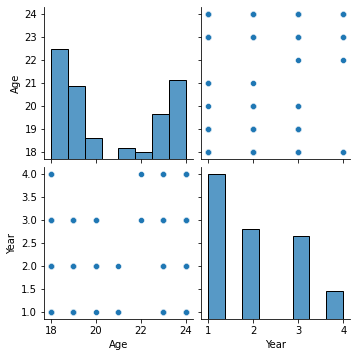

```python
sns.pairplot(data)
```

No outliers, Awesome!

[output not shown]

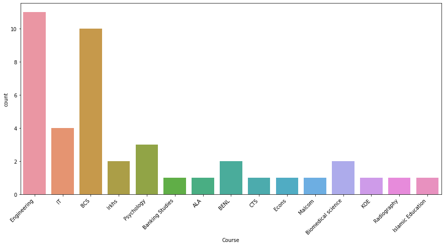

```python
plt.figure(figsize=(15, 7))
chart = sns.countplot(x = 'Course', data = data[data['Year'] == 1])
chart.set_xticklabels(chart.get_xticklabels(), rotation=45, horizontalalignment='right')
```

[output not shown]

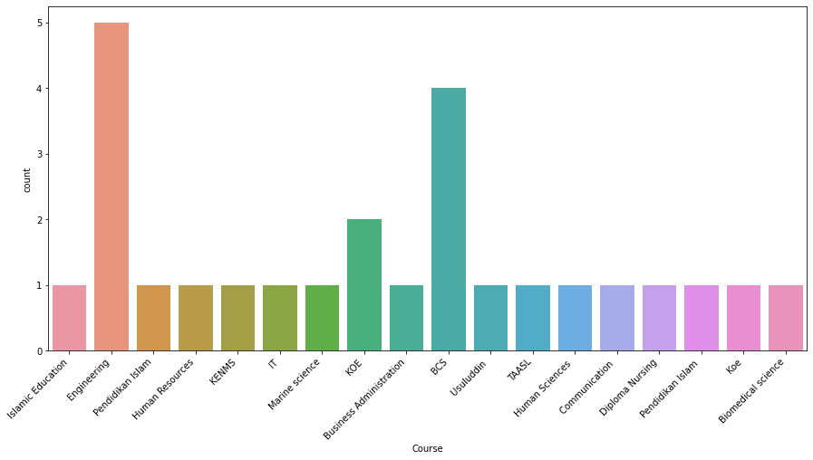

```python
plt.figure(figsize=(15, 7))
chart = sns.countplot(x = 'Course', data = data[data['Year'] == 2])
chart.set_xticklabels(chart.get_xticklabels(), rotation=45, horizontalalignment='right')
```

[output not shown]

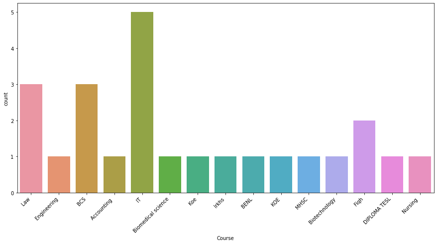

```python
plt.figure(figsize=(15, 7))
chart = sns.countplot(x = 'Course', data = data[data['Year'] == 3])
chart.set_xticklabels(chart.get_xticklabels(), rotation=45, horizontalalignment='right')
```

[output not shown]

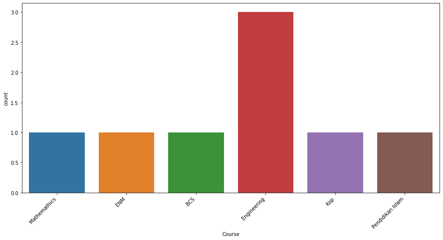

```python
plt.figure(figsize=(15, 7))
chart = sns.countplot(x = 'Course', data = data[data['Year'] == 4])
chart.set_xticklabels(chart.get_xticklabels(), rotation=45, horizontalalignment='right')
```

### Year-wise analysis of students from different courses

##### Here are some of the stats:

- Maximum students from Year 4 are from Engineering.
- Missing Courses from the Year 4 (x-axis) must have a course duration of 3 years.
- Engineering, BCS and IT students rule the survey with maximum number of responses.

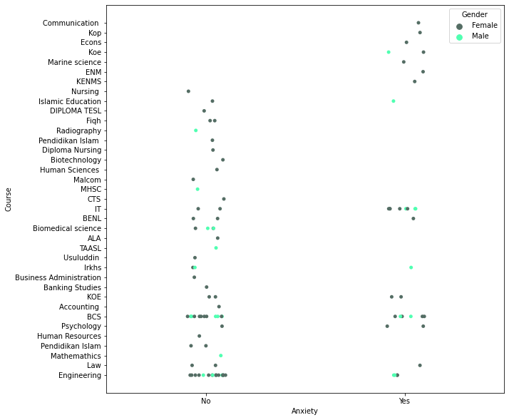

```python
plt.figure(figsize=(10, 10))
sns.stripplot(x = 'Anxiety', y = 'Course', hue = 'Gender', data = data, palette = ['#546D64', '#50FFB1'])
plt.show()
```

### Anxiety vs Course

##### Here are some of the stats:

- Students enrolled in IT experience the maximum anxiety.
- Students enrolled in fields related to Islam(Islamic Education, Pendidikan Islam, Fiqh, Usuluddin, etc.) and Biology(Human Sciences, Nursing, Biomedical Sciences) are less prone to anxiety.
- Computer Science(BCS) has almost an equal number of students who experience anxiety and those who not.

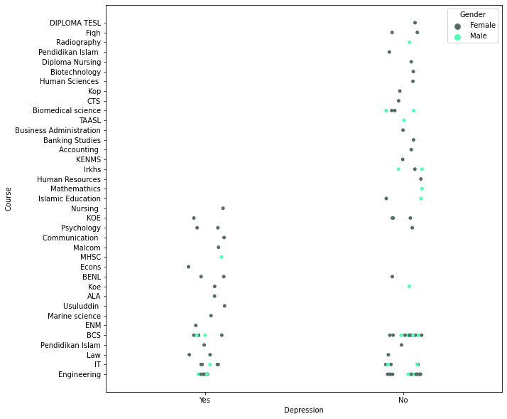

```python
plt.figure(figsize=(10, 10))
sns.stripplot(x = 'Depression', y = 'Course', hue = 'Gender', data = data, palette = ['#546D64', '#50FFB1'])
plt.show()
```

### Depression vs Course

##### Here are some of the stats:

- Males are less prone to experiencing depression as compared to females.
- 2/3 females in Psychology experience depression,... Strange!
- Around 50% of the Students in IT experience depression.

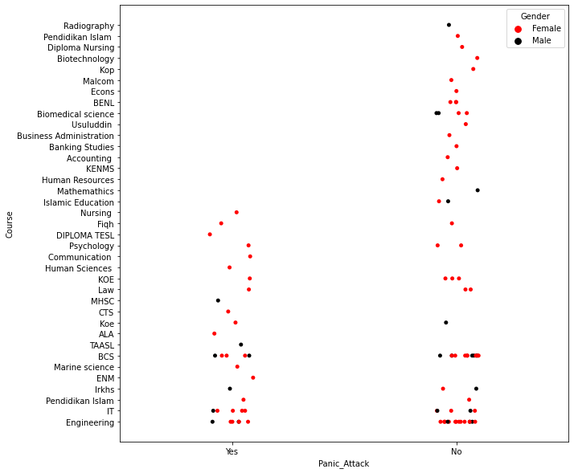

```python
plt.figure(figsize=(10, 10))
sns.stripplot(x = 'Panic_Attack', y = 'Course', hue = 'Gender', data = data, palette = ['red', 'black'])
plt.show()
```

### Panic Attack vs Course

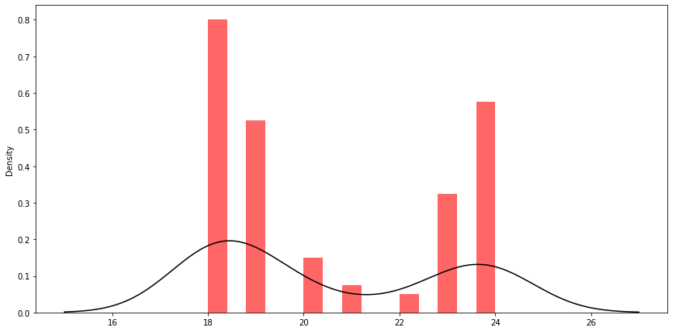

```python
plt.figure(figsize=(14,7))
ax = data["Age"].hist(bins=15, density=True, stacked=True, color='red', alpha=0.6)
data["Age"].plot(kind='density', color='black')
plt.show()
```

**Let's analyse various parameters(Depression, Anxiety, Panic_Attack) yearwise.**

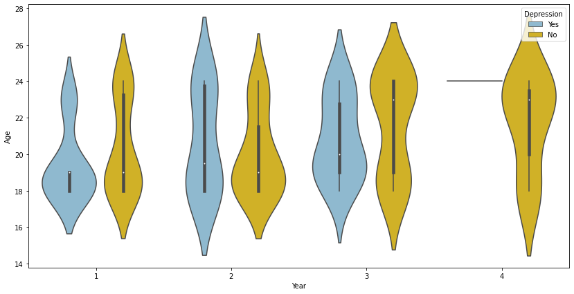

```python
plt.figure(figsize=(14,7))
sns.violinplot(x = 'Year', y = 'Age', data = data,  hue = 'Depression', palette = ['#84BCDA', '#ECC30B'])
plt.show()
```

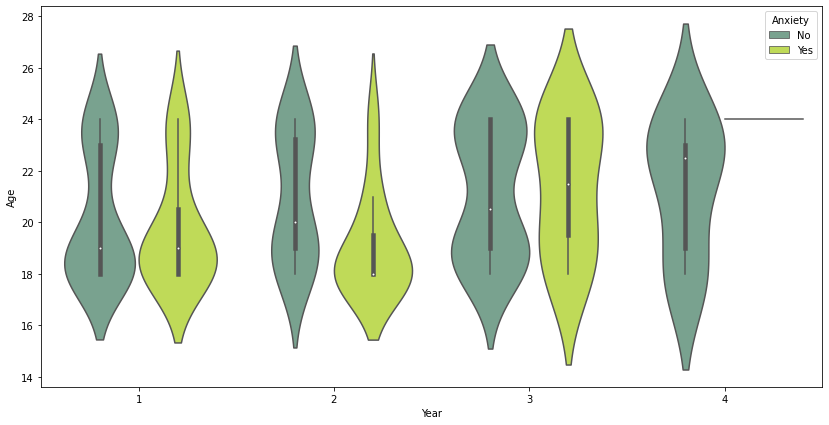

```python
plt.figure(figsize=(14,7))
sns.violinplot(x = 'Year', y = 'Age', data = data,  hue = 'Anxiety', palette = ['#72A98F', '#CBEF43'])
plt.show()
```

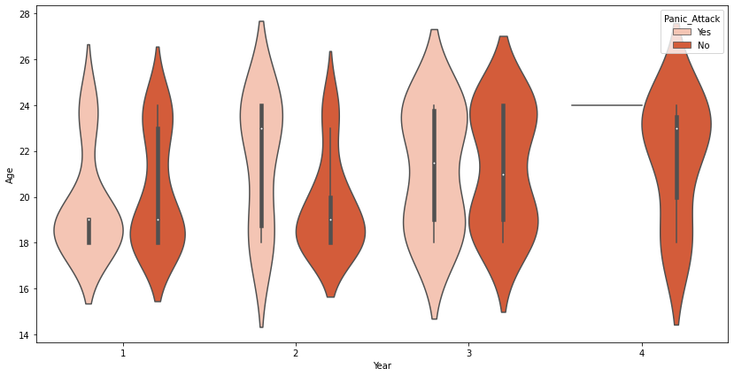

```python
plt.figure(figsize=(14,7))
sns.violinplot(x = 'Year', y = 'Age', data = data,  hue = 'Panic_Attack', palette = ['#FEC0AA', '#EC4E20'])
plt.show()
```

### Key Findings:

- Year 4 students do not experience Depression, Anxiety or Panic Attacks except for those who are aged 24
- Year 3 has a versatile distribution of students. Mixed reviews.
- Year 1 students aged between 18 - 20 experience the most amongst depression, anxiety, panic attacks.
- Year 3 students are more anxiety prone.

**Does CGPA affect mental health?** Let's find out!

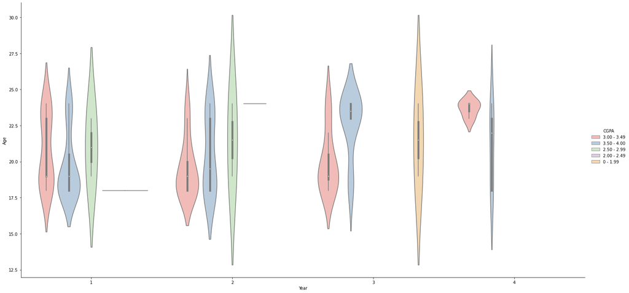

```python
sns.catplot(data=data, x="Year", y="Age", hue="CGPA", kind="violin", palette="Pastel1",height=10,aspect=2)
```

Up next I will plot the classic correlation matrix with a few significant columns.

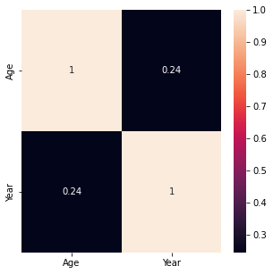

```python
#correlation matrix
corrmat= data.corr()
plt.figure(figsize=(5,5))
sns.heatmap(corrmat,annot=True, cmap=None)
```

### 2.1.4 Data preprocessing

In this section,

##### The following steps are involved:

- we will perform label encoding to the columns (CGPA, Depression, Anxiety, Panick_Attack) to get unique numerical value to each attribute.
- I think we do not require Timestamp, so we'll drop it out.
- Assigning labels and targets.
- Splitting the test and training sets.

```python
data.drop('Timestamp', axis=1, inplace=True)
data.head(20)
```

|  | Gender | Age | Course | Year | CGPA | Marital_Status | Depression | Anxiety | Panic_Attack | Treatment |
| --- | --- | --- | --- | --- | --- | --- | --- | --- | --- | --- |
| 0 | Female | 18.0 | Engineering | 1 | 3.00 - 3.49 | No | Yes | No | Yes | No |
| 1 | Male | 21.0 | Islamic Education | 2 | 3.00 - 3.49 | No | No | Yes | No | No |
| 2 | Male | 19.0 | IT | 1 | 3.00 - 3.49 | No | Yes | Yes | Yes | No |
| 3 | Female | 22.0 | Law | 3 | 3.00 - 3.49 | Yes | Yes | No | No | No |
| 4 | Male | 23.0 | Mathemathics | 4 | 3.00 - 3.49 | No | No | No | No | No |
| 5 | Male | 19.0 | Engineering | 2 | 3.50 - 4.00 | No | No | No | Yes | No |
| 6 | Female | 23.0 | Pendidikan Islam | 2 | 3.50 - 4.00 | Yes | Yes | No | Yes | No |
| 7 | Female | 18.0 | BCS | 1 | 3.50 - 4.00 | No | No | Yes | No | No |
| 8 | Female | 19.0 | Human Resources | 2 | 2.50 - 2.99 | No | No | No | No | No |
| 9 | Male | 18.0 | Irkhs | 1 | 3.50 - 4.00 | No | No | Yes | Yes | No |
| 10 | Female | 20.0 | Psychology | 1 | 3.50 - 4.00 | No | No | No | No | No |
| 11 | Female | 24.0 | Engineering | 3 | 3.50 - 4.00 | Yes | Yes | No | No | No |
| 12 | Female | 18.0 | BCS | 1 | 3.00 - 3.49 | No | Yes | No | No | No |
| 13 | Male | 19.0 | Engineering | 1 | 3.00 - 3.49 | No | No | No | No | No |
| 14 | Female | 18.0 | KENMS | 2 | 3.50 - 4.00 | No | No | Yes | No | No |
| 15 | Male | 24.0 | BCS | 3 | 3.50 - 4.00 | No | No | No | No | No |
| 16 | Female | 24.0 | Accounting | 3 | 3.00 - 3.49 | No | No | No | No | No |
| 17 | Female | 24.0 | ENM | 4 | 3.00 - 3.49 | Yes | Yes | Yes | Yes | No |
| 18 | Female | 20.0 | IT | 2 | 3.50 - 4.00 | No | No | Yes | No | No |
| 19 | Female | 18.0 | Marine science | 2 | 3.50 - 4.00 | Yes | Yes | Yes | Yes | No |

```python
from sklearn.preprocessing import LabelEncoder
encoder = LabelEncoder()
categorical_columns= [x for x in data.columns if data.dtypes[x] == 'object']
for column in categorical_columns:
    data[column] = encoder.fit_transform(data[column])
data.head()
```

|  | Gender | Age | Course | Year | CGPA | Marital_Status | Depression | Anxiety | Panic_Attack | Treatment |
| --- | --- | --- | --- | --- | --- | --- | --- | --- | --- | --- |
| 0 | 0 | 18.0 | 14 | 1 | 3 | 0 | 1 | 0 | 1 | 0 |
| 1 | 1 | 21.0 | 20 | 2 | 3 | 0 | 0 | 1 | 0 | 0 |
| 2 | 1 | 19.0 | 18 | 1 | 3 | 0 | 1 | 1 | 1 | 0 |
| 3 | 0 | 22.0 | 25 | 3 | 3 | 1 | 1 | 0 | 0 | 0 |
| 4 | 1 | 23.0 | 29 | 4 | 3 | 0 | 0 | 0 | 0 | 0 |

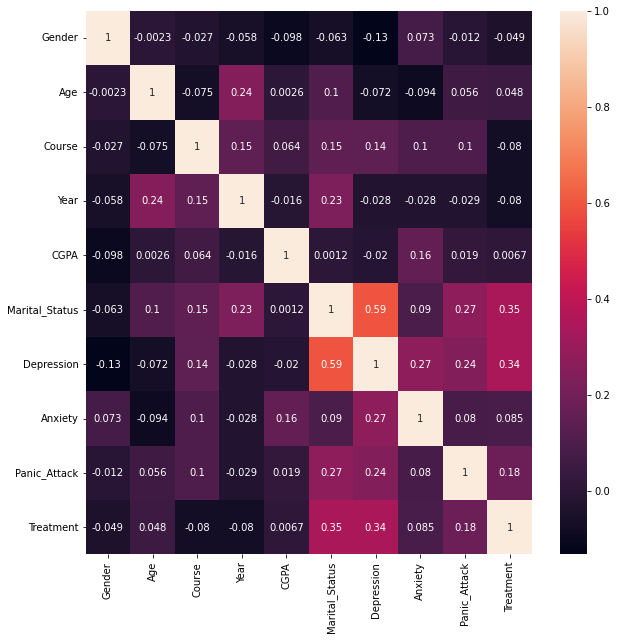

```python
#correlation matrix
corrmat= data.corr()
plt.figure(figsize=(10,10))
sns.heatmap(corrmat,annot=True, cmap=None)
```

### 2.1.5 Model selection

In this section:

```python
X = data.drop(["CGPA"],axis=1)
y = data["CGPA"]

#spliting test and training sets
X_train, X_test, y_train,y_test = train_test_split(X, y, test_size = 0.3, random_state = 42)
```

```python
#A quick model selection process
#pipelines of models( it is short was to fit and pred)
pipeline_lr=Pipeline([('lr_classifier',LogisticRegression(random_state=42))])

pipeline_dt=Pipeline([ ('dt_classifier',DecisionTreeClassifier(random_state=42))])

pipeline_rf=Pipeline([('rf_classifier',RandomForestClassifier())])

pipeline_svc=Pipeline([('sv_classifier',SVC())])

# List of all the pipelines
pipelines = [pipeline_lr, pipeline_dt, pipeline_rf, pipeline_svc]

# Dictionary of pipelines and classifier types for ease of reference
pipe_dict = {0: 'Logistic Regression', 1: 'Decision Tree', 2: 'RandomForest', 3: "SVC"}


# Fit the pipelines
for pipe in pipelines:
    pipe.fit(X_train, y_train)

#cross validation on accuracy
cv_results_accuracy = []
for i, model in enumerate(pipelines):
    cv_score = cross_val_score(model, X_train,y_train, cv=10 )
    cv_results_accuracy.append(cv_score)
    print("%s: %f " % (pipe_dict[i], cv_score.mean()))
```

```
Logistic Regression: 0.557143
Decision Tree: 0.471429
RandomForest: 0.600000
SVC: 0.500000
```

### 2.1.6 Model evaluation

##### The following steps are involved:

- Build a Random Forest model.
- Create classification report.
- Visualize the confusion matrix

```python
#taking look at the test set
pred_rfc = pipeline_rf.predict(X_test)
accuracy = accuracy_score(y_test, pred_rfc)
print(accuracy)
```

```
0.4
```

```python
RF_model = RandomForestClassifier()
RF_model.fit(X_train, y_train)
#Testing the Model on test set
predictions=RF_model.predict(X_test)
acccuracy= accuracy_score(y_test,predictions)
acccuracy
```

```
0.5
```

```python
acccuracy = accuracy_score(y_test, predictions)
recall = recall_score(y_test, predictions, average="weighted")
precision = precision_score(y_test, predictions, average="weighted")
f1_score = f1_score(y_test, predictions, average="micro")

print("********* Random Forest Results *********")
print("Accuracy    : ", acccuracy)
print("Recall      : ", recall)
print("Precision   : ", precision)
print("F1 Score    : ", f1_score)
```

```
********* Random Forest Results *********
Accuracy    :  0.5
Recall      :  0.5
Precision   :  0.4497354497354497
F1 Score    :  0.5
```

```python
print(classification_report(y_test, predictions))
```

```
              precision    recall  f1-score   support

           0       0.00      0.00      0.00         2
           1       0.00      0.00      0.00         1
           2       0.00      0.00      0.00         1
           3       0.48      0.83      0.61        12
           4       0.56      0.36      0.43        14

    accuracy                           0.50        30
   macro avg       0.21      0.24      0.21        30
weighted avg       0.45      0.50      0.45        30
```

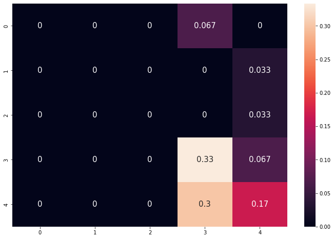

```python
# confusion matrix
plt.subplots(figsize=(12,8))
cf_matrix = confusion_matrix(y_test, predictions)
sns.heatmap(cf_matrix/np.sum(cf_matrix), cmap=None,annot = True, annot_kws = {'size':15})
```

## 2.2. Errores y mejoras de la libreta

A continuación, evaluaremos cuales son los problemas que hemos encontrado en dicha libreta e implementaremos esta de forma correcta. Por último, concluiremos con unas posibles soluciones o mejoras que se podrían implementar.

#### DATA LOADING AND CLEANING

El procedimiento seguido por el autor de la libreta es el siguiente:

1. Carga del conjunto de datos en un dataframe
2. Usa el metodo head para visualizar las primeras instancias
3. Visualiza de conjunto de datos con el método info
4. Visualiza los valores de las variables Year, Course y CGPA y realiza su respectivo preprocesamiento

#### DATA EXPLORATION

En el apartado de Data Exploration podemos observar como el autor de la libreta realiza una exploración en el conjunto de datos buscando outliers, realizando dicha exploración con el conjunto de datos entero creando una fuga de datos. Podemos resumir el proceso seguido por el autor de la siguiente forma:

1. Dado que parte de las variables las analiza individualmente en la anterior etapa, pasa a realizar análisis multivariados donde comienza con las varaibles Age y Year
2. Analiza las variables ya preprocesadas Course y Year, para extraer posibles relaciones
3. Realiza un análisis de las relaciones entre Anxiety, Course y Gender
4. Repite el anterior pero con Depression en lugar de Anxiety
5. Por último, hace lo mismo con Panic_Attack
6. Analiza la relación entre panik_attack y course
7. Realiza más analisis multivariados entre las distintas enfermedades y la variable Year

Desde nuestro punto de vista, en esta fase podemos echar un falta un análisis univariado más extenso para nuestro conjunto de entrenamieto, donde se estudie de forma individual los valores que pueden tomar variables como `Anxiety` o `Depression`, de tal forma que se puedan detectar posibles errores y corregirlos en el preprocesamiento. También sería de vital importancia incluir un análisis de la varaible `CGPA`, que se usará como varaible clasificadora, ya que es determinante saber si esta sigue una distribución equilibrada o no.

En cuanto al análisis multivariado, consideramos que este es bastante extenso y bien llevado a cabo, pero de nuevo, tenemos que destacar que todos estos análisis se han realizado usando el conjunto de datos de forma total, y por lo tanto, causando una fuga de datos.

#### DATA PREPROCESSING

El usuario sigue el siguiente proceso en esta fase:

1. Eliminación de la varaible Timestamp
2. Codificación mediante label encoder de las varaibles de tipo String
3. Visualización del estado de los datos con su preprocesamiento mediante una matriz de correlación

En cuanto a la eliminación de la variable Timestamp, esta no solo se hace fuera de un pipeline, sino que se hace de aplicandose de manera directa al conjunto de datos total, sin separar previamente train y test(de nuevo, fuga de datos).

Esto además, lo hace sin visualizar previamente los valores que toma y su distribución, ya que sin hacer esto no podemos estar seguros si esta variable es útil o no para el modelo (no es el caso ya que en una implementación que hicimos fuera de esta libreta, para un conjunto de entrenamiento formado por 75 instancias 68 eran unique)

En la codificación de variables, el autor de la libreta hace uso del encoder Label Encoder para todas las variables discretas. Esto, desde nuestro punto de vista es erroneo para varaibles como `Course` esta un "orden" entre distintos valores que no deberian tener, por ejemplo para Engineer da un valor como 4 y el modelo generado tendrá en cuenta que está más cerca de otros valores como Law, al que le podría dar un valor como 5 que a otra carrera como IT, con un valor superior, cuando esto no tendria porque ser cierto. Es por ello que nosotros usariamos `OneHotEncoder`, que generaría mas columnas, pero no daría lugar a este problema.

Por último, cabe descatar que echamos de menos el resto de procesamiento necesario en este apartado, que, o bien ha sido llevado a cabo en otros apartados (como el procesamiento de la varaibles `Year` o `Course` a un formato común) , o ha sido omitido y consideramos que es necesario (relleno de valores nulos en todas las varaibles, al no estar seguros si la totalidad de las instancias tienen valores válidos para todas sus variables), todo ello debiendo ser aplicado en un pipeline de tal forma que se pueda aplicar de forma directa el preprocesamiento tanto al conjunto de entrenamiento como al de test.

#### MODEL SELECTION

Es en esta sección cuando el autor de la libreta decide dividir entre train y test. Tras esto, realiza una cross validation con el conjunto de entrenamiento, pero unicamente evaluando 4 modelos seleccionados por el autor, sin realizar un estudio los de los hiperparámetros que permitirian obtener los mejores resultados para cada modelo.

Otro error que podemos destacar es el uso de score únicamente como métrica de rendimiento, que no proporcionará los mejores resultados si la varaible clasificatoria no esta balanceada, siendo preferible el uso de otras como AUC. Dado que en la fase de exploración de datos no se lleva a cabo el estudio de esta, ya que el autor en su libreta solo corrige los valores erroneos, sin observar la distribución de estos, este estudio deberia de ser añadido en la sección de preprocesamiento.

#### MODEL EVALUATION

En esta última sección, el autor usa el modelo que da mejores resultados en la validación cruzada, que en este caso es un `Random Forest`, para estudiar los resultados que obtiene usando el test. De esta se puede destacar la caida del score frente a la obtenida en el apartado anterior. A pesar de ello, debido a la escasa cantidad de instancias de nuestro conjunto de datos, donde solo se entrena con 70 instancias y se testea con 30, hace que no podamos determinar si realmente es el modelo el que causa la caida de rendimiento porque sobreajusta a los datos de entrenamiento o es simplemente el tamaño reducido del test el que los produce.

Cabe destacar que aquí si se hace uso de otras métircas de rendimiento además del score, algo que aporta gran cantidad de información de cara a un estudio completo de los resultados.

#### CONCLUSIÓN Y MEJORAS

Desde nuestro punto de vista, el mayor error cometido por parte del autor es la no separación del train y test, dando lugar a una evidente fuga de datos, que causa que el autor obtenga conclusiones que no debería sobre el conjunto de datos total. El hecho de tratar de predecir, por ejemplo, una instancia de fuera del conjunto de datos podría causar que fallara la predicción, como por ejemplo sucederia si una instancia tiene valores nulos en algunas de sus caracterísiticas. Además de esto, el uso de un pipeline seria imprescindible para realizar un estudio de este tipo.